# Tree Models on Spam Data Set

Homework 1

Mustafa Kaan Aslan

```r
library(tree)
library(rpart)
library(caTools)
library(rpart.plot)
library(kernlab)
```

### “Spam” Data Set

After loading the spam data set, the aim is build a tree model to learn and predict whether a mail is spam or not. The data set consists of 4601 observations. The output variable is the “type” column. “type” is a categorical variable with two levels “spam” and “non-spam”. So, the model will be a classification tree.

```r
data("spam", package = "kernlab")
nrow(spam)
class(spam$type)
levels(spam$type)
```

4601

‘factor’

1. ‘nonspam’
2. ‘spam’

### a) Train and Test Data Sets

```r
nrow(spam[spam$type=="spam",])/nrow(spam)
```

0.394044772875462

- Positive class is “spam” since the model tries to filter the spam mails. The proportion of the spam mails is 0.394, thus there is enough observations to the model to learn, oversampling is not needed. However, the proportion of the positive class should stay constant while splitting into train and test sets. “sample.split” function from the “caTools” library can split the data set while preserving the proportion of the classes.

```r
set.seed(1000)
train <- sample.split(spam$type,0.7)
spam_train <- spam[train,]
spam_test <- spam[!train,]
print("Number of observations in the training set")
nrow(spam_train)
print("Number of observations in the test set")
nrow(spam_test)
print("Proportions")
print("Train")
nrow(spam_train[spam_train$type=="spam",])/nrow(spam_train)
print("Test")
nrow(spam_test[spam_test$type=="spam",])/nrow(spam_test)
```

```
[1] "Number of observations in the training set"
```

3221

```
[1] "Number of observations in the test set"
```

1380

```
[1] "Proportions"
[1] "Train"
```

0.393977025768395

```
[1] "Test"
```

0.394202898550725

### b) Large tree with “rpart”

```r
spam_rpart <- rpart(type~.,method="class",data=spam_train,minbucket=1,minsplit=2, cp=0.0001)
cp_df <- data.frame(spam_rpart$cptable)
tail(cp_df)
```

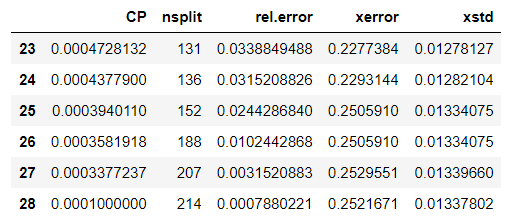

- Using the parameters “minbucket=1”, “minsplit=2” and “cp=0.0001”, the largest tree is obtained with the “rpart()” function. There is 214 splits, so the tree consists of 215 leaf nodes.

### c) Predictions with large tree

```r
pred_spam <- predict(spam_rpart,newdata=spam_test,type="class")
table(spam_test$type,pred_spam)
```

```
         pred_spam
          nonspam spam
  nonspam     761   75
  spam         58  486
```

- False positive rate = 75/836 = 0.0897
- False negative rate = 58/544 = 0.1066
- Error rate = 133/1380 = 0.0963

### d) Cross-validation and pruning

```r
index <- which.min(spam_rpart$cptable[,"xerror"])
index
min_cv <- spam_rpart$cptable[index,"xerror"] + spam_rpart$cptable[index,"xstd"]
min_cv
```

**20:** 20

0.226777547446007

- Summation of the minimum cross-validation error and its standard deviation is 0.226.

```r
cp_df[15,]
cp_df[cp_df$xerror <= min_cv,]
```

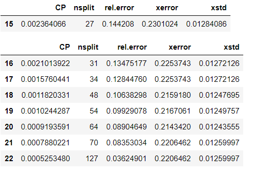

```r
opttree <- prune(spam_rpart,cp=0.0022)
tail(opttree$cptable)
```

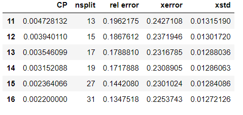

- After the pruning, the optimum tree has 32 leaf nodes.

### e) Predicting with the “opttree”

```r
opt_pred <- predict(opttree,newdata=spam_test,type="class")
table(spam_test$type,opt_pred)
```

```
         opt_pred
          nonspam spam
  nonspam     786   50
  spam         57  487
```

- False positive rate = 50/836 = 0.0598
- False negative rate = 57/544 = 0.1047
- Error rate = 107/1380 = 0.0775
- After the pruning, error rate, false positive rate and false negative rate are decreased. However, the highest decrease is in the false positive rate. Worst scenario is labeling an important mail to a spam mail. So, low false positive rate is preferred.

### b2) Large tree with “tree”

```r
spam_tree <- tree(type~.,spam_train,minsize=2,mincut=1,mindev=0.0001)
summary(spam_tree)
```

```
Classification tree:
tree(formula = type ~ ., data = spam_train, minsize = 2, mincut = 1,
    mindev = 1e-04)
Variables actually used in tree construction:
 [1] "charExclamation"  "remove"           "money"            "george"
 [5] "hp"               "capitalLong"      "free"             "your"
 [9] "email"            "credit"           "will"             "capitalTotal"
[13] "mail"             "direct"           "capitalAve"       "you"
[17] "charSemicolon"    "all"              "internet"         "make"
[21] "address"          "over"             "our"              "num1999"
[25] "charDollar"       "re"               "technology"       "business"
[29] "charRoundbracket" "data"             "edu"              "receive"
[33] "hpl"              "num3d"            "report"           "num85"
[37] "project"          "order"
Number of terminal nodes:  187
Residual mean deviance:  0.0009138 = 2.773 / 3034
Misclassification error rate: 0.0003105 = 1 / 3221
```

- With “tree()” function, the largest tree has 187 leaf nodes.

### c2) Prediction with large tree

```r
pred_spam_tree <- predict(spam_tree,newdata=spam_test,type="class")
table(spam_test$type,pred_spam_tree)
```

```
         pred_spam_tree
          nonspam spam
  nonspam     775   61
  spam         46  498
```

- False positive rate = 61/836 = 0.0729
- False negative rate = 46/544 = 0.0845
- Error rate = 107/1380 = 0.0775

### d2) Cross-validation and pruning

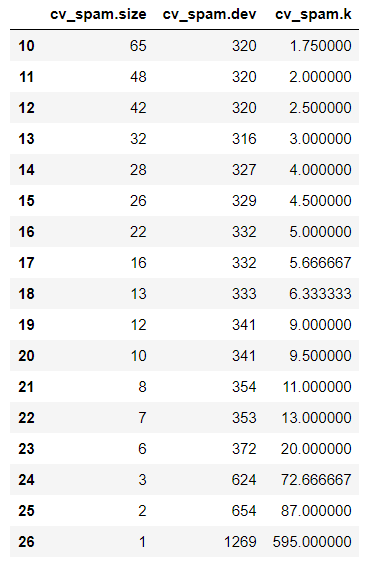

```
[1] "Best size"
```

```r
cv_spam <- cv.tree(spam_tree, K=10, FUN=prune.misclass)
options(repr.plot.width = 4, repr.plot.height = 4)
plot(cv_spam, type="b")
data.frame(cv_spam$size,cv_spam$dev,cv_spam$k)[10:26,]
bestsize <- cv_spam$size[which.min(cv_spam$dev)]
print("Best size")
bestsize
```

32

[figure not shown]

- In order to obtain better results, the model should use the classification error rate in the cross-validation and pruning process. “FUN = prune.misclass” parameter indicates to use classification error rate instead of the default parameter deviance. So, minimum classification error is 316 and the best tree size is 32.

```r
opttree2 <- prune.tree(spam_tree,best=32)
summary(opttree2)
```

```
Classification tree:
snip.tree(tree = spam_tree, nodes = c(27L, 99L, 28L, 129L, 101L,
521L, 256L, 21L, 261L, 776L, 389L, 18L, 98L, 19L, 257L, 20L,
58L, 15L, 1040L, 51L, 100L, 96L, 33L))
Variables actually used in tree construction:
 [1] "charExclamation" "remove"          "money"           "george"
 [5] "hp"              "capitalLong"     "free"            "your"
 [9] "our"             "num1999"         "charDollar"      "re"
[13] "capitalAve"      "you"             "business"        "edu"
[17] "project"
Number of terminal nodes:  32
Residual mean deviance:  0.35 = 1116 / 3189
Misclassification error rate: 0.0652 = 210 / 3221
```

### e2) Predicting with new “opttree”

```r
opt_pred2 <- predict(opttree2,newdata=spam_test,type="class")
table(spam_test$type,opt_pred2)
```

```
         opt_pred2
          nonspam spam
  nonspam     791   45
  spam         79  465
```

PS: In the compiling of cross-validation steps, a new random number is generated. Overall result isn’t changing but deviance measures could have small changes in different compilations. Measurements are taken from first and same ordered compilations.